# Modeling and prediction for movies

## Setup

### Load packages

```r
library(ggplot2)
library(dplyr)
library(statsr)
library(GGally)
library(DAAG)
library(devtools)
```

### Load data

```r
load("movies.Rdata")
```

```r
head(movies)
```

```
## # A tibble: 6 x 32
##   title title_type genre runtime mpaa_rating studio thtr_rel_year thtr_rel_month
##   <chr> <fct>      <fct>   <dbl> <fct>       <fct>          <dbl>          <dbl>
## 1 Fill~ Feature F~ Drama      80 R           Indom~          2013              4
## 2 The ~ Feature F~ Drama     101 PG-13       Warne~          2001              3
## 3 Wait~ Feature F~ Come~      84 R           Sony ~          1996              8
## 4 The ~ Feature F~ Drama     139 PG          Colum~          1993             10
## 5 Male~ Feature F~ Horr~      90 R           Ancho~          2004              9
## 6 Old ~ Documenta~ Docu~      78 Unrated     Shcal~          2009              1
## # ... with 24 more variables: thtr_rel_day <dbl>, dvd_rel_year <dbl>,
## #   dvd_rel_month <dbl>, dvd_rel_day <dbl>, imdb_rating <dbl>,
## #   imdb_num_votes <int>, critics_rating <fct>, critics_score <dbl>,
## #   audience_rating <fct>, audience_score <dbl>, best_pic_nom <fct>,
## #   best_pic_win <fct>, best_actor_win <fct>, best_actress_win <fct>,
## #   best_dir_win <fct>, top200_box <fct>, director <chr>, actor1 <chr>,
## #   actor2 <chr>, actor3 <chr>, actor4 <chr>, actor5 <chr>, imdb_url <chr>,
## #   rt_url <chr>
```

```r
str(movies)
```

```
## tibble [651 x 32] (S3: tbl_df/tbl/data.frame)
##  $ title           : chr [1:651] "Filly Brown" "The Dish" "Waiting for Guffman" "The Age of Innocence" ...
##  $ title_type      : Factor w/ 3 levels "Documentary",..: 2 2 2 2 2 1 2 2 1 2 ...
##  $ genre           : Factor w/ 11 levels "Action & Adventure",..: 6 6 4 6 7 5 6 6 5 6 ...
##  $ runtime         : num [1:651] 80 101 84 139 90 78 142 93 88 119 ...
##  $ mpaa_rating     : Factor w/ 6 levels "G","NC-17","PG",..: 5 4 5 3 5 6 4 5 6 6 ...
##  $ studio          : Factor w/ 211 levels "20th Century Fox",..: 91 202 167 34 13 163 147 118 88 84 ...
##  $ thtr_rel_year   : num [1:651] 2013 2001 1996 1993 2004 ...
##  $ thtr_rel_month  : num [1:651] 4 3 8 10 9 1 1 11 9 3 ...
##  $ thtr_rel_day    : num [1:651] 19 14 21 1 10 15 1 8 7 2 ...
##  $ dvd_rel_year    : num [1:651] 2013 2001 2001 2001 2005 ...
##  $ dvd_rel_month   : num [1:651] 7 8 8 11 4 4 2 3 1 8 ...
##  $ dvd_rel_day     : num [1:651] 30 28 21 6 19 20 18 2 21 14 ...
##  $ imdb_rating     : num [1:651] 5.5 7.3 7.6 7.2 5.1 7.8 7.2 5.5 7.5 6.6 ...
##  $ imdb_num_votes  : int [1:651] 899 12285 22381 35096 2386 333 5016 2272 880 12496 ...
```

[output cut: 18 more lines]

## Part 1: Data

This is an observational study of random samples of movies. As such we can not attribute causation to our analysis. However we can attribute generalization and associations between variables

## Part 2: Research question

** Is there an association between a movie’s run time and its awards and nominations?

## Part 3: Exploratory data analysis

The variables for this analysis are numerical and categorical:

`runtime` (response variable): numerical `best_pic_win` categorical `best_pic_nom`: categorical `best_actor_win`: categorical `best_actress win`: categorical `best_dir_win`: categorical `imdb_rating`: numerical `imdb_num_votes`: numerical `critics_rating`: categorical `critics_score`: numerical `audience_score`: numerical `audience_rating`: categorical

View the shape of the distribution and view the summary statistics of the response variable

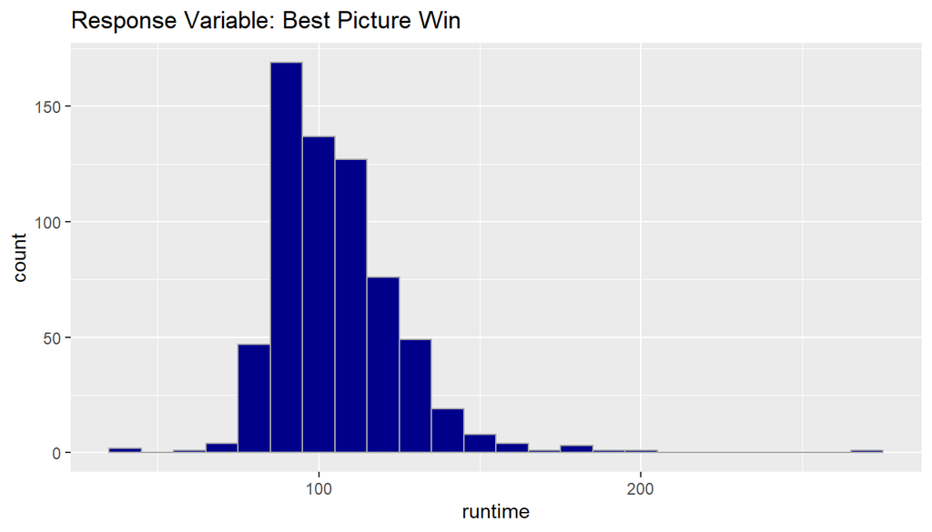

```r
ggplot(data = movies, aes(x = runtime)) +
  geom_histogram(binwidth = 10, color='darkgray', fill  = 'darkblue') +
  labs(title = "Response Variable: Best Picture Win" )
```

```r
summary(movies$runtime)
```

```
##    Min. 1st Qu.  Median    Mean 3rd Qu.    Max.    NA's
##    39.0    92.0   103.0   105.8   115.8   267.0       1
```

The distribution of the response variable is right-skewed with a mean run time of ~106 minutes.

Next, we will check how the other numerical variables are related, looking specifically at the correlation values using a pairwise plot:

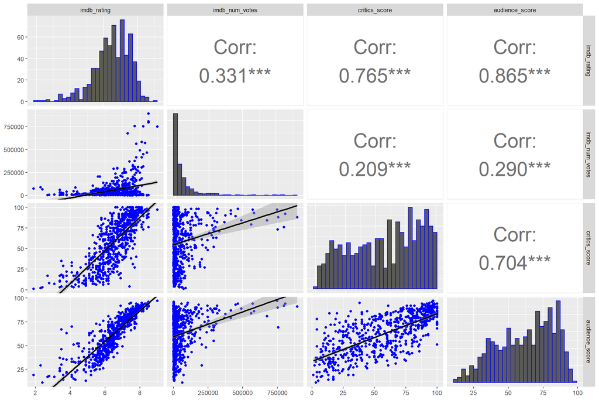

```r
num_cols <- c(13,14,16,18)
ggpairs(movies,
        columns = num_cols,
        upper = list(continuous = wrap("cor", size = 10)),
        diag = list(continuous = wrap("barDiag", color = "blue")),
        lower = list(continuous = wrap("smooth", color = 'blue')))
```

It can be seen here that `imdb_rating`, `audience_score`, and `critics_score` are all strongly correlated. Including more than one of these variables would create multicollinearity into the model. The correlation values for these variables are high (> 0.7), thus including two, or all three of these variables would not significantly improve the predicting power of the model. We will use the `imdb_rating` variable as it has has the highest correlation values.

We will look at the distribution of the variable `imdb_num_votes` as it is not strongly correlated with the other variables:

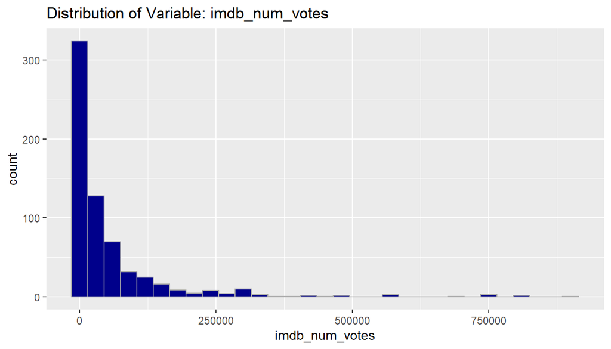

```r
ggplot(data = movies, aes (x = imdb_num_votes)) +
  geom_histogram(binwidth = 30000, color='darkgray', fill  = 'darkblue') +
  labs(title = "Distribution of Variable: imdb_num_votes" )
```

```r
summary(movies$imdb_num_votes)
```

```
##    Min. 1st Qu.  Median    Mean 3rd Qu.    Max.
##     180    4546   15116   57533   58301  893008
```

The data for `imdb_num_votes` is right skewed. Non-normal distributions can be problematic for making inferences about the population; therefore we will use a log transformation for this variable:

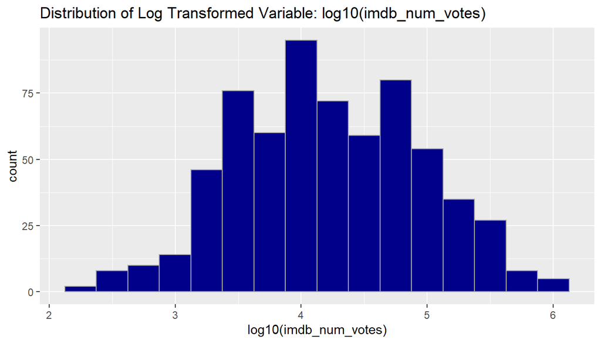

```r
ggplot(data = movies, aes (x = log10(imdb_num_votes))) +
  geom_histogram(binwidth = 0.25, color='darkgray', fill  = 'darkblue') +
  labs(title = "Distribution of Log Transformed Variable: log10(imdb_num_votes)" )
```

The `imdb_num_votes` variable is now nearly normal after the log transformation, and is suitable to use in the model.

NOw we will examine the distribution for `imdb_rating`:

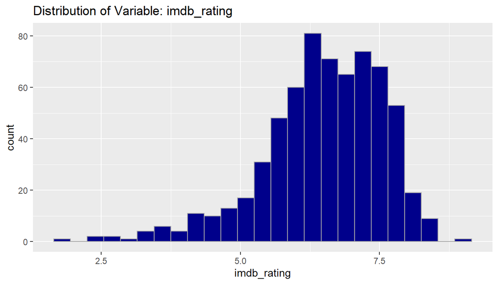

```r
ggplot(data = movies, aes (x = imdb_rating)) +
  geom_histogram(binwidth = 0.3, color='darkgray', fill  = 'darkblue') +
  labs(title = "Distribution of Variable: imdb_rating" )
```

```r
summary(movies$imdb_rating)
```

```
##    Min. 1st Qu.  Median    Mean 3rd Qu.    Max.
##   1.900   5.900   6.600   6.493   7.300   9.000
```

The distribution is nearly normal with a moderate left skew. Given the sample size (n > 30), this skew should not affect any inferences made regarding the population.

The response and explanatory variables need to have a linear dependence For a regression model to be valid. WE can verify this with a scatter plot:

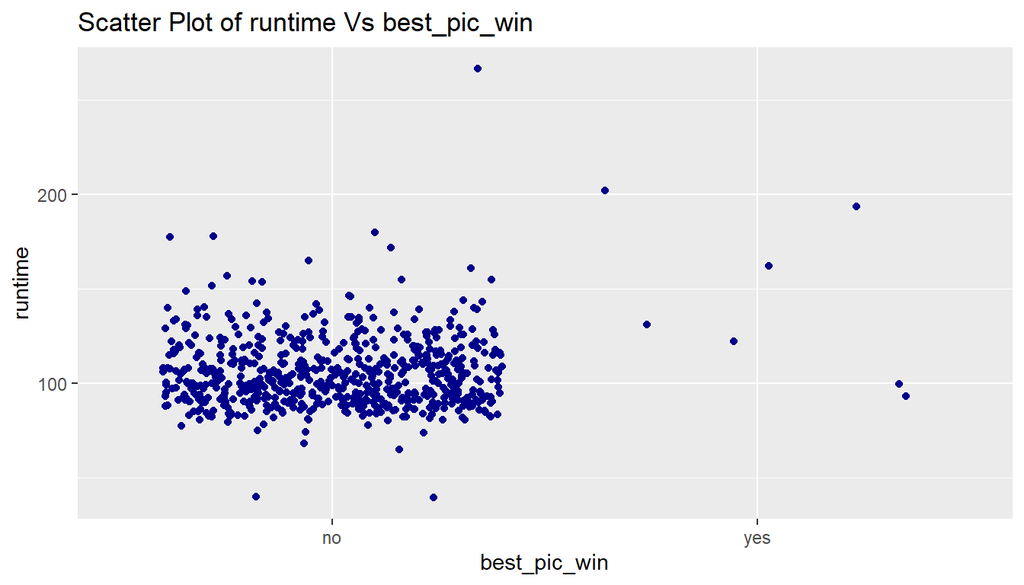

```r
ggplot(data = movies, aes (x = best_pic_win, y = runtime)) +
  geom_jitter(color = 'darkblue') +
  geom_smooth(method = 'lm', formula = y~x, color = 'red') +
  labs(title = "Scatter Plot of runtime Vs best_pic_win" )
```

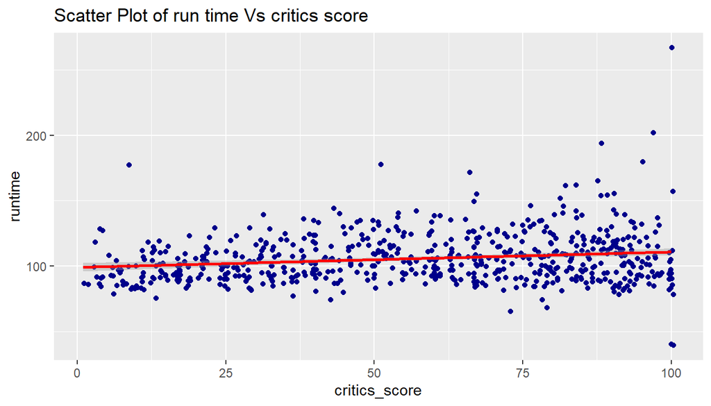

```r
ggplot(data = movies, aes (x = critics_score, y = runtime)) +
  geom_jitter(color = 'darkblue') +
  geom_smooth(method = 'lm', formula = y~x, color = 'red') +
  labs(title = "Scatter Plot of run time Vs critics score" )
```

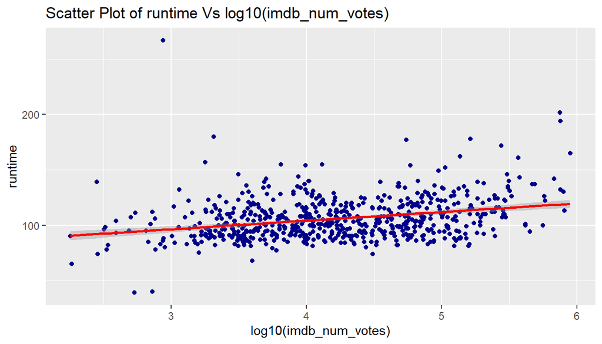

```r
ggplot(data = movies, aes (x = log10(imdb_num_votes), y = runtime)) +
  geom_point(color = 'darkblue') +
  geom_smooth(method = 'lm', formula = y~x, color = 'red') +
  labs(title = "Scatter Plot of runtime Vs log10(imdb_num_votes)" )
```

## Part 4: Modeling

For the model, a backward selection, p-value criteria model selection process will be used. This is because it is a more time efficient method than the $R^{2}$ criteria and forward selection process when there are numerous variables in the model. As the model results will be used as more of a guideline rather than a strict value - a significance level of alpha = 0.2 will be used.

The full model and summary statistics are given below:

```r
full_model = lm(runtime ~ best_actor_win +
                  best_actress_win+
                  best_dir_win +
                  best_pic_nom +
                  imdb_rating +
                  log10(imdb_num_votes) +
                  critics_rating +
                  critics_score +
                  audience_rating +
                  audience_score
                , data = movies)
summary(full_model)
```

```
##
## Call:
## lm(formula = runtime ~ best_actor_win + best_actress_win + best_dir_win +
##     best_pic_nom + imdb_rating + log10(imdb_num_votes) + critics_rating +
##     critics_score + audience_rating + audience_score, data = movies)
##
## Residuals:
##     Min      1Q  Median      3Q     Max
## -60.684 -10.183  -2.229   9.160 163.061
##
## Coefficients:
##                        Estimate Std. Error t value Pr(>|t|)
## (Intercept)            49.14830    7.85600   6.256 7.24e-10 ***
## best_actor_winyes       9.45240    1.97409   4.788 2.09e-06 ***
## best_actress_winyes     6.96024    2.20350   3.159 0.001659 **
## best_dir_winyes        11.52561    2.78961   4.132 4.08e-05 ***
## best_pic_nomyes        14.13466    4.01597   3.520 0.000463 ***
## imdb_rating             6.03384    1.43388   4.208 2.95e-05 ***
## log10(imdb_num_votes)   4.79705    1.05633   4.541 6.69e-06 ***
## critics_ratingFresh     2.74977    2.13177   1.290 0.197552
## critics_ratingRotten    5.85456    3.41684   1.713 0.087117 .
## critics_score           0.03725    0.06154   0.605 0.545162
## audience_ratingUpright  3.26016    2.76887   1.177 0.239461
## audience_score         -0.22074    0.09714  -2.273 0.023387 *
## ---
## Signif. codes:  0 '***' 0.001 '**' 0.01 '*' 0.05 '.' 0.1 ' ' 1
##
## Residual standard error: 17.04 on 638 degrees of freedom
##   (1 observation deleted due to missingness)
## Multiple R-squared:  0.2455, Adjusted R-squared:  0.2325
## F-statistic: 18.87 on 11 and 638 DF,  p-value: < 2.2e-16
```

`critics_score` variable has a high p-values it will be removed from the model :

```r
model_2 = lm(runtime ~ best_actor_win +
                  best_actress_win+
                  best_dir_win +
                  best_pic_nom +
                  imdb_rating +
                  log10(imdb_num_votes) +
                  critics_rating +
                  audience_rating +
                  audience_score
                  , data = movies)
summary((model_2))
```

```
##
## Call:
## lm(formula = runtime ~ best_actor_win + best_actress_win + best_dir_win +
##     best_pic_nom + imdb_rating + log10(imdb_num_votes) + critics_rating +
##     audience_rating + audience_score, data = movies)
##
## Residuals:
##     Min      1Q  Median      3Q     Max
## -60.100 -10.094  -2.034   9.023 163.504
##
## Coefficients:
##                        Estimate Std. Error t value Pr(>|t|)
## (Intercept)            50.36454    7.59097   6.635 6.93e-11 ***
## best_actor_winyes       9.48103    1.97254   4.807 1.92e-06 ***
## best_actress_winyes     7.00522    2.20115   3.183 0.001531 **
## best_dir_winyes        11.58169    2.78669   4.156 3.68e-05 ***
## best_pic_nomyes        14.17433    4.01344   3.532 0.000443 ***
## imdb_rating             6.37219    1.31980   4.828 1.73e-06 ***
## log10(imdb_num_votes)   4.67022    1.03484   4.513 7.61e-06 ***
## critics_ratingFresh     2.46880    2.07959   1.187 0.235607
## critics_ratingRotten    4.30743    2.26668   1.900 0.057840 .
## audience_ratingUpright  3.23254    2.76712   1.168 0.243163
## audience_score         -0.21926    0.09706  -2.259 0.024214 *
## ---
## Signif. codes:  0 '***' 0.001 '**' 0.01 '*' 0.05 '.' 0.1 ' ' 1
##
## Residual standard error: 17.03 on 639 degrees of freedom
##   (1 observation deleted due to missingness)
## Multiple R-squared:  0.2451, Adjusted R-squared:  0.2333
## F-statistic: 20.74 on 10 and 639 DF,  p-value: < 2.2e-16
```

`critcs_rating` and `audience_rating` have high p-values after this iteration and will not be used in the final model.

```r
final_model = lm(runtime ~ best_actor_win +
                  best_actress_win+
                  best_dir_win +
                  best_pic_nom +
                  imdb_rating +
                  log10(imdb_num_votes) +
                  audience_score
                  , data = movies)
summary((final_model))
```

```
##
## Call:
## lm(formula = runtime ~ best_actor_win + best_actress_win + best_dir_win +
##     best_pic_nom + imdb_rating + log10(imdb_num_votes) + audience_score,
##     data = movies)
##
## Residuals:
##     Min      1Q  Median      3Q     Max
## -59.546 -10.238  -2.088   9.249 164.577
##
## Coefficients:
##                       Estimate Std. Error t value Pr(>|t|)
## (Intercept)           57.55137    6.07280   9.477  < 2e-16 ***
## best_actor_winyes      9.57665    1.96684   4.869 1.41e-06 ***
## best_actress_winyes    7.01089    2.19996   3.187 0.001508 **
## best_dir_winyes       11.31280    2.77811   4.072 5.24e-05 ***
## best_pic_nomyes       13.17372    3.97612   3.313 0.000974 ***
## imdb_rating            5.55931    1.24745   4.457 9.83e-06 ***
## log10(imdb_num_votes)  4.42770    0.97575   4.538 6.79e-06 ***
## audience_score        -0.15768    0.06648  -2.372 0.017992 *
## ---
## Signif. codes:  0 '***' 0.001 '**' 0.01 '*' 0.05 '.' 0.1 ' ' 1
##
## Residual standard error: 17.05 on 642 degrees of freedom
##   (1 observation deleted due to missingness)
## Multiple R-squared:  0.2396, Adjusted R-squared:  0.2313
## F-statistic: 28.89 on 7 and 642 DF,  p-value: < 2.2e-16
```

Coefficients in the model represent an increase or decrease in minutes for predicted runtimes; the increase/decrease is for per unit for numerical variables. Categorical variables levels but one are set to zero and the increase/decrease from remaining level added to the model.

Certain conditions have to be met for the model to be valid:

1. Linear relationships between (numerical) x and y
2. Nearly normal residuals with mean 0
3. Constant variability of residuals
4. Independent residuals

The first condition has been verified by the previous scatter plots of the numerical variables. The condition for nearly normal residuals can be checked using histogram and/or Q-Q plot of the residuals:

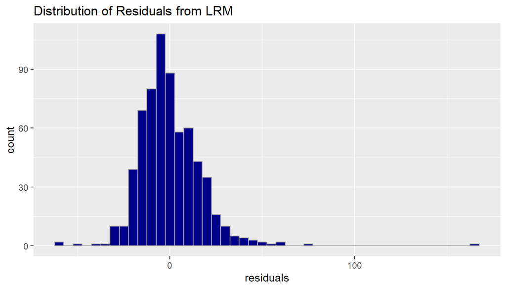

```r
ggplot(data = final_model, aes(x = final_model$residuals)) +
  geom_histogram(color = 'darkgray', fill = 'darkblue', binwidth = 5)  +
  labs(x = "residuals", title = "Distribution of Residuals from LRM" )
```

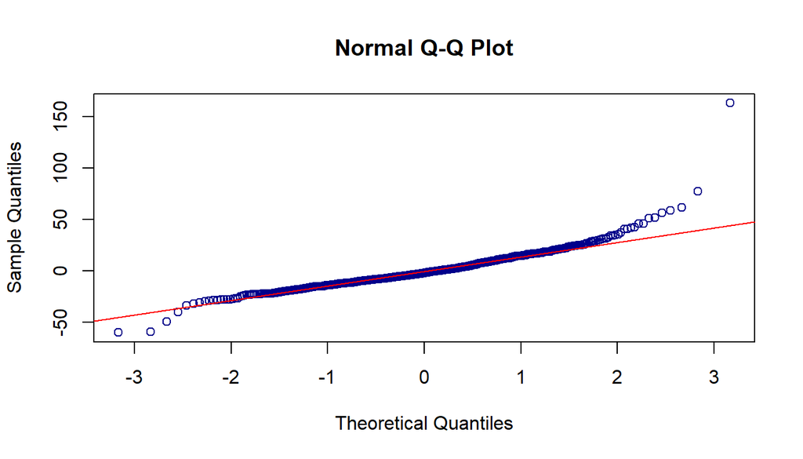

```r
qqnorm(model_2$residuals, col = 'darkblue')
qqline(model_2$residuals, col = 'red')
```

```r
summary(model_2$residuals)
```

```
##    Min. 1st Qu.  Median    Mean 3rd Qu.    Max.
## -60.100 -10.094  -2.034   0.000   9.023 163.504
```

The mean of the residuals equal zero. The histogram does show that the residuals right skewed due to a small proportion of outliers. The Q-Q plot also indicates an almost normal distribution with some deviation on the right hand side showing that the data is right skewed. Both plots show a nearly normal distribution as the skew is from several extreme data points. Condition 2 has been met.

The variability of residuals can be checked by plotting the residuals against the predicted values from the model as seen below:

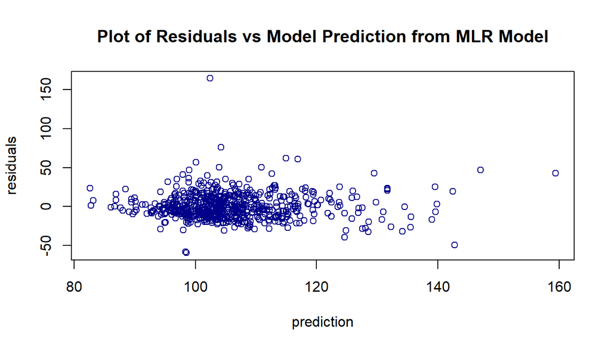

```r
plot(final_model$residuals ~ final_model$fitted,
     main = 'Plot of Residuals vs Model Prediction from MLR Model',
     xlab = 'prediction',
     ylab = 'residuals',
     col = 'darkblue')
```

The variability of residuals is not constant. The values for the standard error are not entirely accurate and could affect the accuracy of confidence intervals and the outcome of hypothesis tests from the model. If the model was altered to take into account the non-constancy that is present, then this would resolve this issue, however, this is beyond the scope of this project.

To check independent residuals (condition 4) plot the residuals as they appear in the data which will reveal any time series dependences:

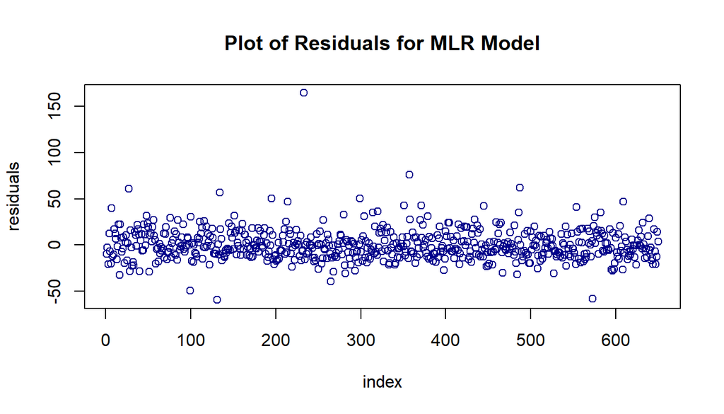

```r
plot(final_model$residuals,
     main = 'Plot of Residuals for MLR Model',
     xlab = 'index',
     ylab = 'residuals',
     col = 'darkblue')
```

The residuals are distributed randomly and are independent.

## Part 5: Prediction

The model can now be used to predict the running time of a movie not present in the sample data. The chosen test movie is The Royal Tenenbaums (2002).

As mentioned previously, a 80% confidence interval will be used for the model prediction:

```r
 tenebaums = data.frame(best_actor_win = 'no',
                     best_actress_win = 'no',
                     best_dir_win = 'no',
                     imdb_rating = 7.6,
                     imdb_num_votes = 201779,
                     best_pic_nom = 'no',
                    audience_score = 89,
                     stringsAsFactors=FALSE)
predict(final_model,
        tenebaums,
        interval = "prediction",
        level = 0.8)
```

```
##        fit      lwr      upr
## 1 109.2571 87.29169 131.2226
```

## Part 6: Conclusion

The prediction of the model is correct in this instance. With the movie ‘The Royal Tenenbaums’ having a runtime of 110 minutes. The explanatory variables are predictors of runtime, and can be used to predict runtime to a certain degree of accuracy. There are several caveats however. First the confidence level for the given interval may be lower than stated in reality due to the variability in the residuals. Second the Adjusted $R^{2}$ value for the model is 0.23; ~77% of the variability of the data is not explained by the model, thus its predictive efficacy is poor.

Mastering techniques to normalize the data better may result in a improved model.